# Live coding 5

Andrew Irwin

2021-02-04 8:35

# Agenda

- Questions arising from lessons, tasks
- Examples from lessons 12, 13, 14: reshaping data, displaying tables, and getting help
- Live coding examples of pivoting tools (`pivot_longer`, `pivot_wider`, `unite` and `separate`), formatting tables (`kable`, `kableExtra`) – material for tasks 7 and 8
- Strategies for getting help and learning independently (for Assignment 2)

The plan for the live coding is for us to work together to solve problems using tools from this week’s lessons. As with last week, we’ll start with some repeated examples from lessons to remind ourselves of the basics, then try to use the tools in new ways, and finally switch perspectives to try to solve a real problem with each tool.

## Reshaping data

Let’s use the `mpg` data from the tidyverse. It’s always good to have a variety of data to work with to test your understanding of new functions, so I’ve collected the datasets we’ve been using (and a few more) in their own chapter called Data sources.

This brief way of summarizing the data is great for seeing as much of the data as possible in a small space.

```r
glimpse(mpg)
```

```
## Rows: 234
## Columns: 11
## $ manufacturer <chr> "audi", "audi", "audi", "audi", "audi", "audi", "audi", …
## $ model        <chr> "a4", "a4", "a4", "a4", "a4", "a4", "a4", "a4 quattro", …
## $ displ        <dbl> 1.8, 1.8, 2.0, 2.0, 2.8, 2.8, 3.1, 1.8, 1.8, 2.0, 2.0, 2…
## $ year         <int> 1999, 1999, 2008, 2008, 1999, 1999, 2008, 1999, 1999, 20…
## $ cyl          <int> 4, 4, 4, 4, 6, 6, 6, 4, 4, 4, 4, 6, 6, 6, 6, 6, 6, 8, 8,…
## $ trans        <chr> "auto(l5)", "manual(m5)", "manual(m6)", "auto(av)", "aut…
## $ drv          <chr> "f", "f", "f", "f", "f", "f", "f", "4", "4", "4", "4", "…
## $ cty          <int> 18, 21, 20, 21, 16, 18, 18, 18, 16, 20, 19, 15, 17, 17, …
## $ hwy          <int> 29, 29, 31, 30, 26, 26, 27, 26, 25, 28, 27, 25, 25, 25, …
## $ fl           <chr> "p", "p", "p", "p", "p", "p", "p", "p", "p", "p", "p", "…
## $ class        <chr> "compact", "compact", "compact", "compact", "compact", "…
```

The lower-density table version is probably a better way to look a table if we are going to think about reshaping from long to wide format.

```r
mpg %>% head()
```

```
## # A tibble: 6 x 11
##   manufacturer model displ  year   cyl trans      drv     cty   hwy fl    class
##   <chr>        <chr> <dbl> <int> <int> <chr>      <chr> <int> <int> <chr> <chr>
## 1 audi         a4      1.8  1999     4 auto(l5)   f        18    29 p     compa…
## 2 audi         a4      1.8  1999     4 manual(m5) f        21    29 p     compa…
## 3 audi         a4      2    2008     4 manual(m6) f        20    31 p     compa…
## 4 audi         a4      2    2008     4 auto(av)   f        21    30 p     compa…
## 5 audi         a4      2.8  1999     6 auto(l5)   f        16    26 p     compa…
## 6 audi         a4      2.8  1999     6 manual(m5) f        18    26 p     compa…
```

Let’s make a table that lists manufacturer, model, and then in two columns the average city fuel consumption for each year in the data.

First we compute average fuel consumption for each combination of manufacturer, model, and year. Then pivot the data to make a wider table (it will be 38 rows by 4 columns when we are done). Store the result in your environment by giving the new table a name, so that we can use formatting tools in the next section to display it nicely.

```r
table1 <- mpg  %>% group_by(model, manufacturer, year) %>%
  summarise(avg_mpg_city = mean(cty))   %>%
  pivot_wider(names_from = year, values_from = avg_mpg_city)
table1
```

```
## # A tibble: 38 x 4
## # Groups:   model, manufacturer [38]
##    model              manufacturer `1999` `2008`
##    <chr>              <chr>         <dbl>  <dbl>
##  1 4runner 4wd        toyota         15.2   15
##  2 a4                 audi           18.2   19.7
##  3 a4 quattro         audi           16.5   17.8
##  4 a6 quattro         audi           15     16.5
##  5 altima             nissan         20     21
##  6 c1500 suburban 2wd chevrolet      13     12.8
##  7 camry              toyota         19.5   20.3
##  8 camry solara       toyota         19.5   20.3
##  9 caravan 2wd        dodge          16.2   15.4
## 10 civic              honda          24.8   24
## # … with 28 more rows
```

Clean up the “trans”mission column to put the parenthetical codes (av, l5, m6, etc) in their own column using separate.

```r
mpg %>% separate(trans, into = c("trans_type", "trans_code"), sep ="\\(", remove = FALSE) %>%
  mutate(trans_code = str_remove(trans_code, "\\)"))
```

```
## # A tibble: 234 x 13
##    manufacturer model displ  year   cyl trans trans_type trans_code drv     cty
##    <chr>        <chr> <dbl> <int> <int> <chr> <chr>      <chr>      <chr> <int>
##  1 audi         a4      1.8  1999     4 auto… auto       l5         f        18
##  2 audi         a4      1.8  1999     4 manu… manual     m5         f        21
##  3 audi         a4      2    2008     4 manu… manual     m6         f        20
##  4 audi         a4      2    2008     4 auto… auto       av         f        21
##  5 audi         a4      2.8  1999     6 auto… auto       l5         f        16
##  6 audi         a4      2.8  1999     6 manu… manual     m5         f        18
##  7 audi         a4      3.1  2008     6 auto… auto       av         f        18
##  8 audi         a4 q…   1.8  1999     4 manu… manual     m5         4        18
##  9 audi         a4 q…   1.8  1999     4 auto… auto       l5         4        16
## 10 audi         a4 q…   2    2008     4 manu… manual     m6         4        20
## # … with 224 more rows, and 3 more variables: hwy <int>, fl <chr>, class <chr>
```

To practice make wide data longer, we should start with a different dataset.

The `co2` data has monthly observations of atmospheric CO2 from 1959 to 1997.

```r
co2
```

```
##         Jan    Feb    Mar    Apr    May    Jun    Jul    Aug    Sep    Oct
## 1959 315.42 316.31 316.50 317.56 318.13 318.00 316.39 314.65 313.68 313.18
## 1960 316.27 316.81 317.42 318.87 319.87 319.43 318.01 315.74 314.00 313.68
## 1961 316.73 317.54 318.38 319.31 320.42 319.61 318.42 316.63 314.83 315.16
## 1962 317.78 318.40 319.53 320.42 320.85 320.45 319.45 317.25 316.11 315.27
## 1963 318.58 318.92 319.70 321.22 322.08 321.31 319.58 317.61 316.05 315.83
## 1964 319.41 320.07 320.74 321.40 322.06 321.73 320.27 318.54 316.54 316.71
## 1965 319.27 320.28 320.73 321.97 322.00 321.71 321.05 318.71 317.66 317.14
## 1966 320.46 321.43 322.23 323.54 323.91 323.59 322.24 320.20 318.48 317.94
## 1967 322.17 322.34 322.88 324.25 324.83 323.93 322.38 320.76 319.10 319.24
## 1968 322.40 322.99 323.73 324.86 325.40 325.20 323.98 321.95 320.18 320.09
## 1969 323.83 324.26 325.47 326.50 327.21 326.54 325.72 323.50 322.22 321.62
## 1970 324.89 325.82 326.77 327.97 327.91 327.50 326.18 324.53 322.93 322.90
## 1971 326.01 326.51 327.01 327.62 328.76 328.40 327.20 325.27 323.20 323.40
## 1972 326.60 327.47 327.58 329.56 329.90 328.92 327.88 326.16 324.68 325.04
```

[output cut: 65 more lines]

This is a time series object, which is displayed as a rectangle, but does not have variable names and doesn’t work like a data frame (or tibble).

Suppose instead, someone gave you this data formatted as a data frame with each month in its own column:

```r
co2M <- matrix(co2, 39, 12, byrow = TRUE)
colnames(co2M) <- c("Jan", "Feb", "Mar", "Apr", "May", "Jun",
                    "Jul", "Aug", "Sep", "Oct", "Nov", "Dec")
co2DF <- as_tibble(co2M) %>% mutate(Year = 1959:1997) %>% select(Year, everything())
co2DF
```

```
## # A tibble: 39 x 13
##     Year   Jan   Feb   Mar   Apr   May   Jun   Jul   Aug   Sep   Oct   Nov   Dec
##    <int> <dbl> <dbl> <dbl> <dbl> <dbl> <dbl> <dbl> <dbl> <dbl> <dbl> <dbl> <dbl>
##  1  1959  315.  316.  316.  318.  318.  318   316.  315.  314.  313.  315.  315.
##  2  1960  316.  317.  317.  319.  320.  319.  318.  316.  314   314.  315.  316.
##  3  1961  317.  318.  318.  319.  320.  320.  318.  317.  315.  315.  316.  317.
##  4  1962  318.  318.  320.  320.  321.  320.  319.  317.  316.  315.  317.  318.
##  5  1963  319.  319.  320.  321.  322.  321.  320.  318.  316.  316.  317.  318.
##  6  1964  319.  320.  321.  321.  322.  322.  320.  319.  317.  317.  318.  319.
##  7  1965  319.  320.  321.  322.  322   322.  321.  319.  318.  317.  319.  319.
##  8  1966  320.  321.  322.  324.  324.  324.  322.  320.  318.  318.  320.  321.
##  9  1967  322.  322.  323.  324.  325.  324.  322.  321.  319.  319.  321.  322.
## 10  1968  322.  323.  324.  325.  325.  325.  324.  322.  320.  320.  321.  323.
## # … with 29 more rows
```

Now, use `pivot_longer` to reshape this into a “tidy” data frame with a column for year, a column for month, and a column for CO2 concentration.

```r
co2DF %>% select(Jun:Aug, Oct:Dec, everything())
```

```
## # A tibble: 39 x 13
##      Jun   Jul   Aug   Oct   Nov   Dec  Year   Jan   Feb   Mar   Apr   May   Sep
##    <dbl> <dbl> <dbl> <dbl> <dbl> <dbl> <int> <dbl> <dbl> <dbl> <dbl> <dbl> <dbl>
##  1  318   316.  315.  313.  315.  315.  1959  315.  316.  316.  318.  318.  314.
##  2  319.  318.  316.  314.  315.  316.  1960  316.  317.  317.  319.  320.  314
##  3  320.  318.  317.  315.  316.  317.  1961  317.  318.  318.  319.  320.  315.
##  4  320.  319.  317.  315.  317.  318.  1962  318.  318.  320.  320.  321.  316.
##  5  321.  320.  318.  316.  317.  318.  1963  319.  319.  320.  321.  322.  316.
##  6  322.  320.  319.  317.  318.  319.  1964  319.  320.  321.  321.  322.  317.
##  7  322.  321.  319.  317.  319.  319.  1965  319.  320.  321.  322.  322   318.
##  8  324.  322.  320.  318.  320.  321.  1966  320.  321.  322.  324.  324.  318.
##  9  324.  322.  321.  319.  321.  322.  1967  322.  322.  323.  324.  325.  319.
## 10  325.  324.  322.  320.  321.  323.  1968  322.  323.  324.  325.  325.  320.
## # … with 29 more rows
```

```r
co2Y <- co2DF %>% # select(Year, Jun:Aug, Oct:Dec) %>%
  pivot_longer(cols = Jan:Dec, names_to= "month", values_to = "pCO2")
co2Y
```

```
## # A tibble: 468 x 3
##     Year month  pCO2
##    <int> <chr> <dbl>
##  1  1959 Jan    315.
##  2  1959 Feb    316.
##  3  1959 Mar    316.
##  4  1959 Apr    318.
##  5  1959 May    318.
##  6  1959 Jun    318
##  7  1959 Jul    316.
##  8  1959 Aug    315.
##  9  1959 Sep    314.
## 10  1959 Oct    313.
## # … with 458 more rows
```

## Formatting tables

Compute the average annual pCO2 for each year, then show this as a table. Add a caption.

```r
co2Y %>% group_by(Year) %>% summarise(mean_pCO2 = mean(pCO2)) %>%
  kable(digits = 1,
        caption = "Annual average pCO2.") %>%
  kable_styling(bootstrap = "striped",
                full_width = FALSE)
```

Annual average pCO2.

| Year | mean_pCO2 |
| --- | --- |
| 1959 | 315.8 |
| 1960 | 316.7 |
| 1961 | 317.5 |
| 1962 | 318.3 |
| 1963 | 318.8 |
| 1964 | 319.5 |
| 1965 | 319.9 |
| 1966 | 321.2 |
| 1967 | 322.0 |
| 1968 | 322.9 |
| 1969 | 324.5 |
| 1970 | 325.5 |
| 1971 | 326.2 |
| 1972 | 327.3 |
| 1973 | 329.5 |
| 1974 | 330.1 |
| 1975 | 331.0 |
| 1976 | 332.0 |
| 1977 | 333.7 |
| 1978 | 335.3 |
| 1979 | 336.7 |
| 1980 | 338.5 |
| 1981 | 339.8 |
| 1982 | 341.0 |
| 1983 | 342.6 |
| 1984 | 344.2 |
| 1985 | 345.7 |
| 1986 | 347.0 |
| 1987 | 348.8 |
| 1988 | 351.3 |
| 1989 | 352.8 |
| 1990 | 354.0 |
| 1991 | 355.5 |
| 1992 | 356.3 |
| 1993 | 357.0 |
| 1994 | 358.9 |
| 1995 | 360.9 |
| 1996 | 362.7 |
| 1997 | 363.8 |

Compute the average by decade, discarding partial decades (1950s and 1990s).

```r
co2Y %>% filter(Year >= 1960, Year < 1990) %>%
  mutate(decade = floor(Year/10)*10) %>%
  group_by(decade) %>%
  summarize(mean_pco2 = mean(pCO2)) %>%
  kable(digits = 2,
        caption = "Decadal average pCO2 at Mauna Loa") %>%
  kable_styling(full_width = FALSE, bootstrap_options = "striped")
```

Decadal average pCO2 at Mauna Loa

| decade | mean_pco2 |
| --- | --- |
| 1960 | 320.13 |
| 1970 | 330.73 |
| 1980 | 345.16 |

Find the lowest and highest pCO2 for each year and show that in a table.

```r
co2Y %>% group_by(Year) %>%
  summarize(minimum = min(pCO2),
                maximum = max(pCO2)) %>%
  kable() %>% kable_styling(bootstrap_options = "basic", full_width = FALSE)
```

| Year | minimum | maximum |
| --- | --- | --- |
| 1959 | 313.18 | 318.13 |
| 1960 | 313.68 | 319.87 |
| 1961 | 314.83 | 320.42 |
| 1962 | 315.27 | 320.85 |
| 1963 | 315.83 | 322.08 |
| 1964 | 316.54 | 322.06 |
| 1965 | 317.14 | 322.00 |
| 1966 | 317.94 | 323.91 |
| 1967 | 319.10 | 324.83 |
| 1968 | 320.09 | 325.40 |
| 1969 | 321.62 | 327.21 |
| 1970 | 322.90 | 327.97 |
| 1971 | 323.20 | 328.76 |
| 1972 | 324.68 | 329.90 |
| 1973 | 327.02 | 332.31 |
| 1974 | 327.21 | 332.92 |
| 1975 | 328.17 | 333.80 |
| 1976 | 328.78 | 334.71 |
| 1977 | 330.98 | 336.57 |
| 1978 | 332.38 | 337.84 |
| 1979 | 333.70 | 339.30 |
| 1980 | 335.72 | 341.29 |
| 1981 | 336.52 | 342.74 |
| 1982 | 337.69 | 343.96 |
| 1983 | 339.69 | 345.58 |
| 1984 | 340.90 | 347.25 |
| 1985 | 342.62 | 348.74 |
| 1986 | 343.99 | 350.03 |
| 1987 | 346.18 | 351.66 |
| 1988 | 348.55 | 354.04 |
| 1989 | 349.64 | 355.52 |
| 1990 | 350.82 | 357.00 |
| 1991 | 352.05 | 359.22 |
| 1992 | 352.94 | 359.58 |
| 1993 | 353.67 | 360.23 |
| 1994 | 355.84 | 361.67 |
| 1995 | 357.80 | 363.82 |
| 1996 | 359.51 | 365.45 |
| 1997 | 360.24 | 366.84 |

Return to the `mpg` dataset and make some nice looking tables.

Look at the examples [here](https://cran.r-project.org/web/packages/kableExtra/vignettes/awesome_table_in_html.html) and experiment with some of the formatting options. Use `mpg` instead of `mtcars`.

## Getting help

Pick a task related to something you know how to do and try to learn how to do this.

Use the following methods:

### Read a help page in Rstudio

A good idea here is to think of a function you know a bit about and read its help page.

```r
round(0.5)
```

```
## [1] 0
```

```r
signif(pi, 4)
```

```
## [1] 3.142
```

### Read the documentation for ggplot at the tidyverse

Try geom_quantile - from the cheatsheet.

```
## Smoothing formula not specified. Using: y ~ x
```

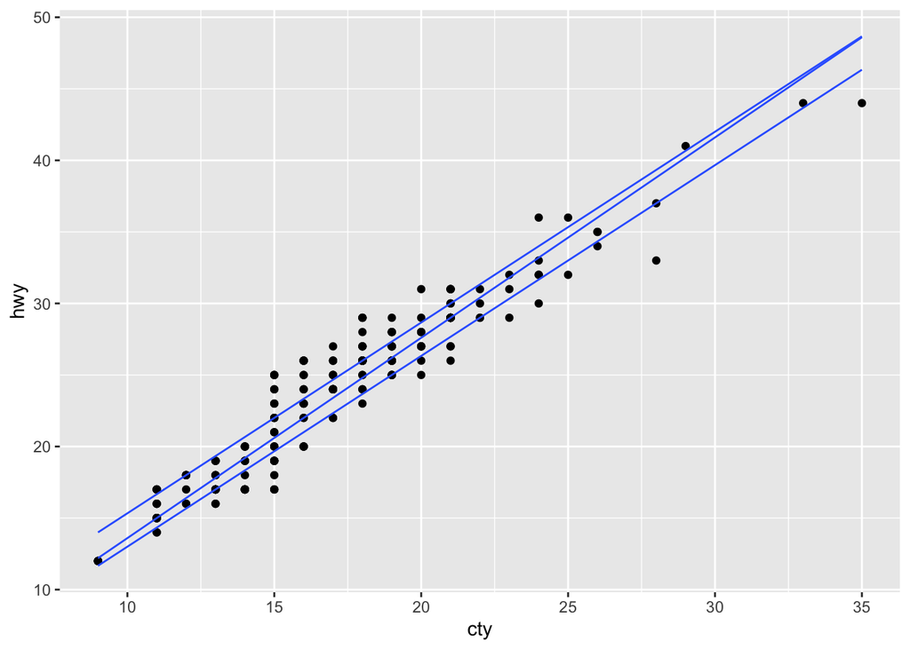

```r
mpg %>% ggplot(aes(cty, hwy)) + geom_point() + geom_quantile()
```

### Look at a figure in the R Graph Gallery

And try to reconstruct it.

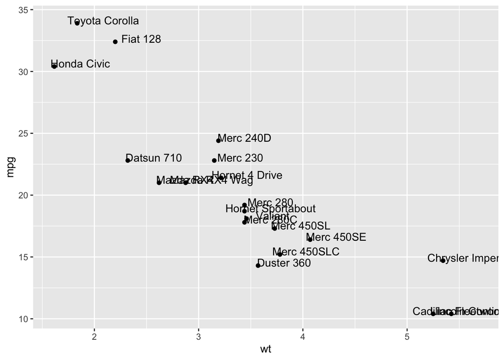

```r
data=head(mtcars, 20)
ggplot(data, aes(x=wt, y=mpg)) +
  geom_point() + # Show dots
  geom_text(
    label=rownames(data),
    nudge_x = 0.25, nudge_y = 0.25,
    check_overlap = FALSE
  )
```

```r
library(gapminder)
gapminder %>% filter(country %in% c("Canada", "Brazil", "China"))
```

```
## # A tibble: 36 x 6
##    country continent  year lifeExp       pop gdpPercap
##    <fct>   <fct>     <int>   <dbl>     <int>     <dbl>
##  1 Brazil  Americas   1952    50.9  56602560     2109.
##  2 Brazil  Americas   1957    53.3  65551171     2487.
##  3 Brazil  Americas   1962    55.7  76039390     3337.
##  4 Brazil  Americas   1967    57.6  88049823     3430.
##  5 Brazil  Americas   1972    59.5 100840058     4986.
##  6 Brazil  Americas   1977    61.5 114313951     6660.
##  7 Brazil  Americas   1982    63.3 128962939     7031.
##  8 Brazil  Americas   1987    65.2 142938076     7807.
##  9 Brazil  Americas   1992    67.1 155975974     6950.
## 10 Brazil  Americas   1997    69.4 168546719     7958.
## # … with 26 more rows
```

```r
gapminder %>% filter(country == "Canada" | country == "Brazil" | country == "China") # same result
```

```
## # A tibble: 36 x 6
##    country continent  year lifeExp       pop gdpPercap
##    <fct>   <fct>     <int>   <dbl>     <int>     <dbl>
##  1 Brazil  Americas   1952    50.9  56602560     2109.
##  2 Brazil  Americas   1957    53.3  65551171     2487.
##  3 Brazil  Americas   1962    55.7  76039390     3337.
##  4 Brazil  Americas   1967    57.6  88049823     3430.
##  5 Brazil  Americas   1972    59.5 100840058     4986.
##  6 Brazil  Americas   1977    61.5 114313951     6660.
##  7 Brazil  Americas   1982    63.3 128962939     7031.
##  8 Brazil  Americas   1987    65.2 142938076     7807.
##  9 Brazil  Americas   1992    67.1 155975974     6950.
## 10 Brazil  Americas   1997    69.4 168546719     7958.
## # … with 26 more rows
```